# Predict survival of patients with heart failure

## 7.5 Estymacja modelu z wykorzystaniem zmiennych istotnych statystycznie oraz spełniających założenie o proporcjonalności

```r
  cox1_po_procjonalnosci <- coxph(formula = Surv(time, DEATH_EVENT) ~ age + anaemia + creatinine_phosphokinase +
     high_blood_pressure + serum_creatinine +
    serum_sodium, data = data)
  summary(cox1_po_procjonalnosci)
```

```
## Call:
## coxph(formula = Surv(time, DEATH_EVENT) ~ age + anaemia + creatinine_phosphokinase +
##     high_blood_pressure + serum_creatinine + serum_sodium, data = data)
##
##   n= 299, number of events= 96
##
##                                coef  exp(coef)   se(coef)      z Pr(>|z|)
## age                       0.0415451  1.0424201  0.0086897  4.781 1.74e-06 ***
## anaemia1                  0.3701085  1.4478917  0.2162295  1.712  0.08696 .
## creatinine_phosphokinase  0.0002041  1.0002041  0.0001010  2.020  0.04335 *
## high_blood_pressure1      0.4727181  1.6043490  0.2154819  2.194  0.02825 *
## serum_creatinine          0.2469241  1.2800819  0.0591050  4.178 2.94e-05 ***
## serum_sodium             -0.0680724  0.9341929  0.0208784 -3.260  0.00111 **
## ---
## Signif. codes:  0 '***' 0.001 '**' 0.01 '*' 0.05 '.' 0.1 ' ' 1
##
##                          exp(coef) exp(-coef) lower .95 upper .95
## age                         1.0424     0.9593    1.0248    1.0603
## anaemia1                    1.4479     0.6907    0.9477    2.2120
## creatinine_phosphokinase    1.0002     0.9998    1.0000    1.0004
## high_blood_pressure1        1.6043     0.6233    1.0517    2.4475
## serum_creatinine            1.2801     0.7812    1.1401    1.4373
## serum_sodium                0.9342     1.0704    0.8967    0.9732
##
## Concordance= 0.707  (se = 0.028 )
## Likelihood ratio test= 56.81  on 6 df,   p=2e-10
## Wald test            = 63.27  on 6 df,   p=1e-11
## Score (logrank) test = 68.78  on 6 df,   p=7e-13
```

### 7.5.1 Graficzna weryfikacja założenia proporcjonalności

Metoda skalowanych reszt Schoenfelda jest jednym z najczęściej stosowanych narzędzi do weryfikacji założenia proporcjonalności hazardów w modelu Coxa. Reszty te mierzą różnicę między obserwowanymi a oczekiwanymi wartościami zmiennych dla jednostek, które doświadczyły zdarzenia

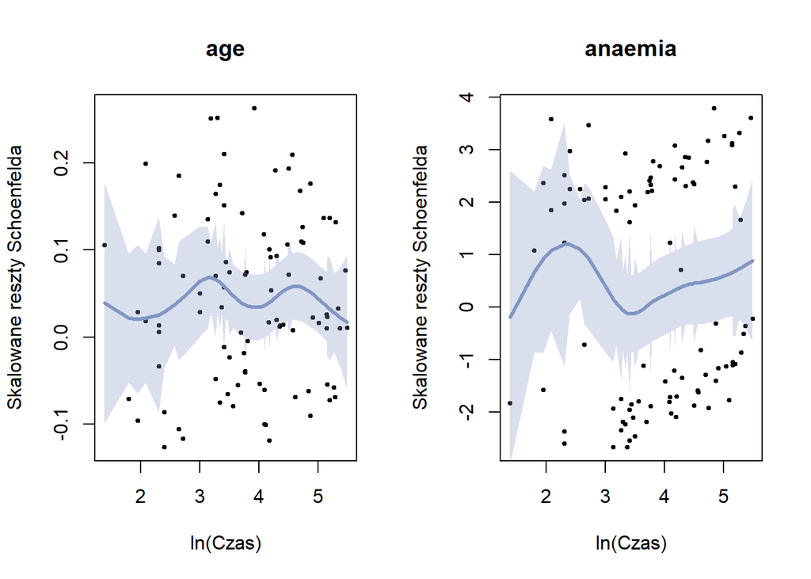

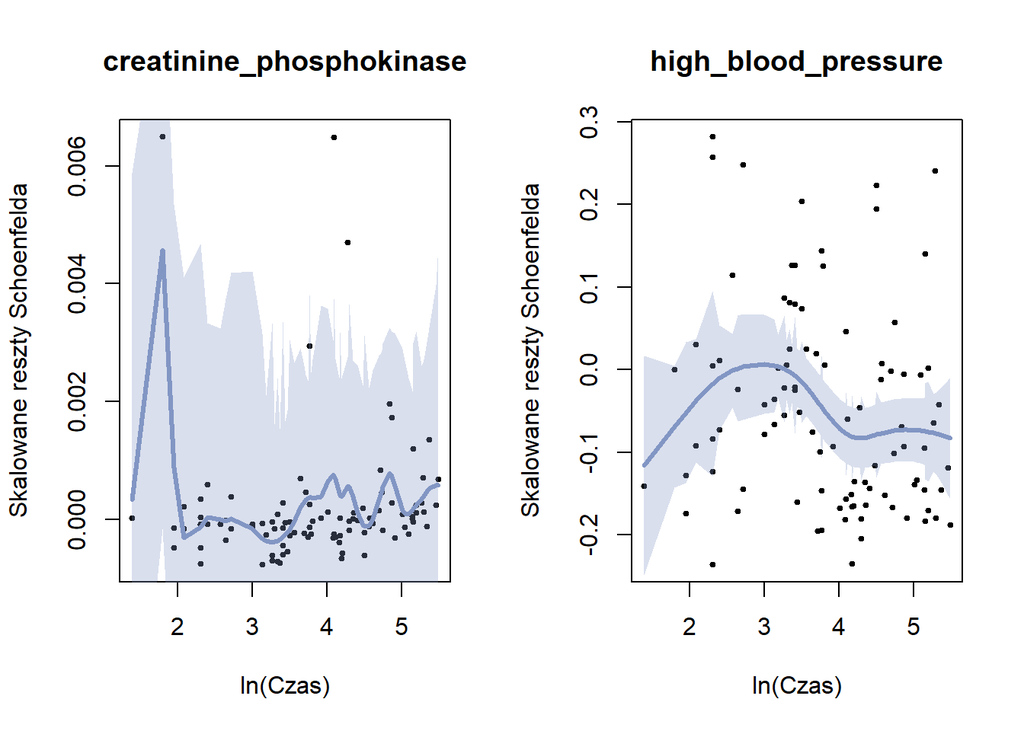

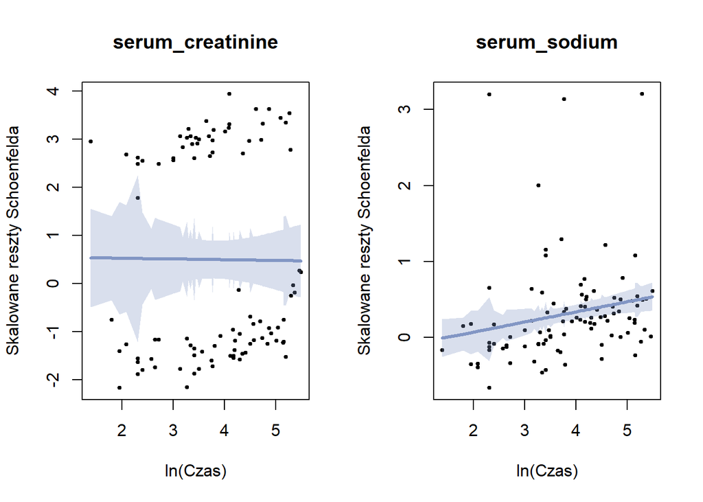

```r
     reszty <- resid(cox1_po_AIC, type="scaledsch")
     Time <- as.numeric(rownames(reszty))
     zmienne <- names(data[,c(1,2,3,6,8,9)])

     par(mfrow = c(1,2))
     for (i in 1:6) {
       plot(log(Time), reszty[,i], xlab="ln(Czas)", main=zmienne[i],
            ylab="Skalowane reszty Schoenfelda", pch=20, cex=0.7)
       lines(smooth.spline(log(Time), reszty[,i] ), lwd=3 )
     }
```

## 7.6 Identyfikacja jednostek odstających

Jednostki odstające mogą mieć istotny wpływ na wyniki modelu proporcjonalnych hazardów (PH) Coxa. Ich identyfikacja i odpowiednia analiza pomagają w poprawie jakości dopasowania modelu oraz wiarygodności uzyskanych oszacowań.Są to obserwacje na wykresach wyraźnie oddalone od pozostałych. Charakteryzują się nietypową kombinacją zmiennych objaśniających i mogą mieć nadmierny wpływ na oszacowania parametrów modelu

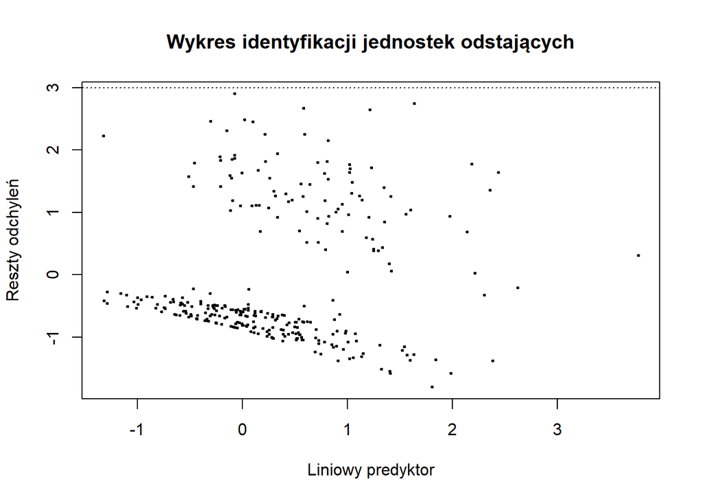

```r
     deviance <- residuals(cox1_po_procjonalnosci,type="deviance")
     s <- cox1_po_procjonalnosci$linear.predictors
     plot(s,deviance,main = "Wykres identyfikacji jednostek odstających", xlab="Liniowy predyktor",ylab="Reszty odchyleń",cex=0.5, pch=20)
     abline(h=c(3,-3),lty=3)
```

```r
     data$deviance <- deviance
     c1 <- which(data$deviance< c(-3))
```

## 7.7 Jednostki wpływowe

Jednostki wpływowe to obserwacje, które mają znaczący wpływ na oszacowania parametrów modelu. Mogą one powodować znaczne zmiany w wynikach analizy. Z próby usuwamy jednostki o numerach: 2, 13, 18, 20, 26, 29, 53, 61, 67, 132, 132, 218, 229, 229, 236, 290

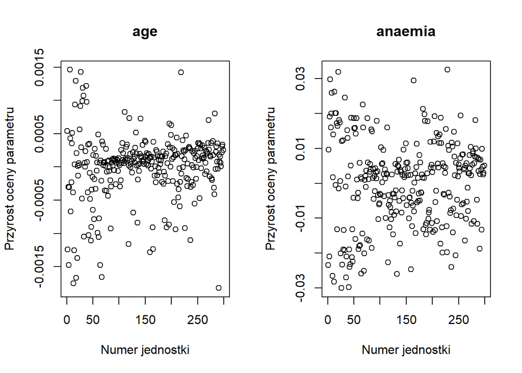

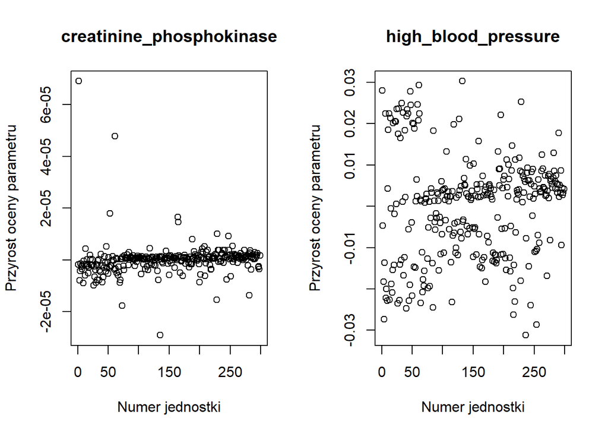

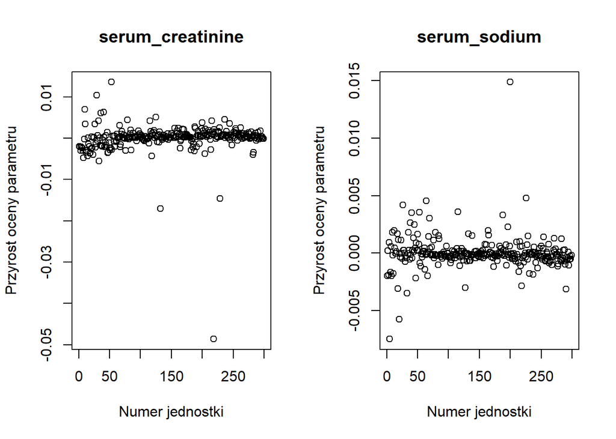

```r
     dfb <- residuals(cox1_po_procjonalnosci,type="dfbeta")
     n <- dim(dfb)[1]
     obs.nr <- c(1:n)
     par(mfrow = c(1,2))
     for (j in 1:6) {
       plot(obs.nr,dfb[,j],xlab="Numer jednostki",ylab="Przyrost oceny parametru",
            main=zmienne[j])
     }
```

```r
     a1 <- which(abs(dfb[,1])>(0.0015)) #usunac te jednostki
     a2 <- which(abs(dfb[,2])>(0.03))
     a3 <- which(abs(dfb[,3])>(0.00004))
     a4 <- which(abs(dfb[,4])>(0.03))
     a5 <- which(abs(dfb[,5])>(0.01))
     a6 <- which(abs(dfb[,5])>(0.010))

     c <- sort(unique(c(a1,a2,a3,a4,a5,c1)))
     data_1 <- data[-c,] #zredukowany zbior
```

### 7.7.1 Oszacowanie modelu na zredukowanej ilości jednostek

**Interpretacja:**

**Anemia (anaemia):**

Pacjenci z anemią mają hazard o 48,4% wyższy (HR = 1.484) w porównaniu do pacjentów bez anemii. Zmienna ta jest marginalnie istotna (p = 0.07974).

**Fosfokinaza kreatynowa (creatinine_phosphokinase):**

Wzrost poziomu fosfokinazy kreatynowej o 1 jednostkę nie wpływa istotnie na hazard (HR ≈ 1.0002, p = 0.88554).

**Uwagi dotyczące dopasowania modelu:** **Konkordancja (C-index):**

Wartość 0.74 wskazuje na dobrą zdolność modelu do rozróżniania pacjentów o różnym ryzyku zgonu.

**Testy istotności:**

**Test współczynnika wiarygodności (Likelihood ratio test):** p < 0.001. **Test Walda:** p < 0.001. **Test log-rank:** p < 0.001.

Wszystkie testy potwierdzają, że model jest statystycznie istotny.

**Podsumowanie:**

Wiek, kreatynina w surowicy oraz poziom sodu w surowicy to kluczowe zmienne istotne statystycznie, które mają największy wpływ na ryzyko zgonu. Anemia jest marginalnie istotna i wymaga dalszej analizy. Fosfokinaza kreatynowa nie wykazuje istotnego wpływu na hazard w tej zredukowanej bazie danych.

**Model jest dobrze dopasowany (C-index = 0.74) i spełnia założenia proporcjonalności hazardów.**

```r
     Cox_jednostki_wplywowe <-  coxph(formula = Surv(time, DEATH_EVENT) ~ age + anaemia + creatinine_phosphokinase +
     high_blood_pressure + serum_creatinine +
     serum_sodium, data = data_1)
     summary(Cox_jednostki_wplywowe)
```

```
## Call:
## coxph(formula = Surv(time, DEATH_EVENT) ~ age + anaemia + creatinine_phosphokinase +
##     high_blood_pressure + serum_creatinine + serum_sodium, data = data_1)
##
##   n= 285, number of events= 86
##
##                                coef  exp(coef)   se(coef)      z Pr(>|z|)
## age                       5.030e-02  1.052e+00  9.783e-03  5.141 2.73e-07 ***
## anaemia1                  3.942e-01  1.483e+00  2.250e-01  1.752  0.07974 .
## creatinine_phosphokinase -2.396e-05  1.000e+00  1.665e-04 -0.144  0.88554
## high_blood_pressure1      5.583e-01  1.748e+00  2.263e-01  2.467  0.01363 *
## serum_creatinine          3.798e-01  1.462e+00  8.671e-02  4.380 1.19e-05 ***
## serum_sodium             -6.231e-02  9.396e-01  2.328e-02 -2.676  0.00745 **
## ---
## Signif. codes:  0 '***' 0.001 '**' 0.01 '*' 0.05 '.' 0.1 ' ' 1
##
##                          exp(coef) exp(-coef) lower .95 upper .95
## age                         1.0516     0.9509    1.0316    1.0719
## anaemia1                    1.4832     0.6742    0.9543    2.3052
## creatinine_phosphokinase    1.0000     1.0000    0.9996    1.0003
## high_blood_pressure1        1.7478     0.5722    1.1216    2.7236
## serum_creatinine            1.4619     0.6840    1.2334    1.7327
## serum_sodium                0.9396     1.0643    0.8977    0.9835
##
## Concordance= 0.74  (se = 0.027 )
## Likelihood ratio test= 69.65  on 6 df,   p=5e-13
## Wald test            = 85.32  on 6 df,   p=3e-16
## Score (logrank) test = 93.71  on 6 df,   p=<2e-16
```

## 7.8 Akaike

**Podsumowanie:**

- Finalny model zawiera 5 zmiennych, które najlepiej opisują ryzyko zgonu w badanej populacji.
- Istotne statystycznie zmienne: wiek, nadciśnienie, kreatynina w surowicy, sód w surowicy.
- Zmienne marginalnie istotne: anemia (p = 0.07333).

**Model jest dobrze dopasowany (C-index = 0.74), a procedura krokowa z użyciem AIC pozwoliła na optymalizację liczby zmiennych przy zachowaniu wysokiej jakości predykcji.**

```r
     stepAIC(Cox_jednostki_wplywowe,direction="backward")
```

```
## Start:  AIC=845.69
## Surv(time, DEATH_EVENT) ~ age + anaemia + creatinine_phosphokinase +
##     high_blood_pressure + serum_creatinine + serum_sodium
##
##                            Df    AIC
## - creatinine_phosphokinase  1 843.71
## <none>                        845.69
## - anaemia                   1 846.73
## - high_blood_pressure       1 849.57
## - serum_sodium              1 850.19
## - serum_creatinine          1 857.02
## - age                       1 869.90
##
## Step:  AIC=843.71
## Surv(time, DEATH_EVENT) ~ age + anaemia + high_blood_pressure +
##     serum_creatinine + serum_sodium
##
##                       Df    AIC
## <none>                   843.71
## - anaemia              1 844.88
## - high_blood_pressure  1 847.69
## - serum_sodium         1 848.20
## - serum_creatinine     1 855.31
## - age                  1 867.91
```

```
## Call:
## coxph(formula = Surv(time, DEATH_EVENT) ~ age + anaemia + high_blood_pressure +
##     serum_creatinine + serum_sodium, data = data_1)
##
##                           coef exp(coef)  se(coef)      z        p
## age                   0.050213  1.051495  0.009764  5.143 2.71e-07
## anaemia1              0.398909  1.490198  0.222762  1.791  0.07333
## high_blood_pressure1  0.561402  1.753128  0.225453  2.490  0.01277
## serum_creatinine      0.381244  1.464104  0.086036  4.431 9.37e-06
## serum_sodium         -0.062217  0.939679  0.023238 -2.677  0.00742
##
## Likelihood ratio test=69.63  on 5 df, p=1.224e-13
## n= 285, number of events= 86
```

# 8 Metoda reszt martyngalowych - badamy czy wystepuje liniowość

Metoda reszt martyngalowych pozwala na identyfikację jednostek, które mogą być trudne do dopasowania w analizie przeżycia. Reszty te pokazują różnicę między rzeczywistymi a przewidywanymi wartościami zmiennej zależnej (czas przeżycia) w modelu. Jeżeli zmienna objaśniająca 𝑋 jest ilościowa, to wprowadzenie jej do modelu Coxa, jest równoważne przyjęciu założenia, że łączy ją związek liniowy z logarytmem hazardu

## 8.1 Reszty martyngałowe dla zmiennej age

**age - występuje liniowość**

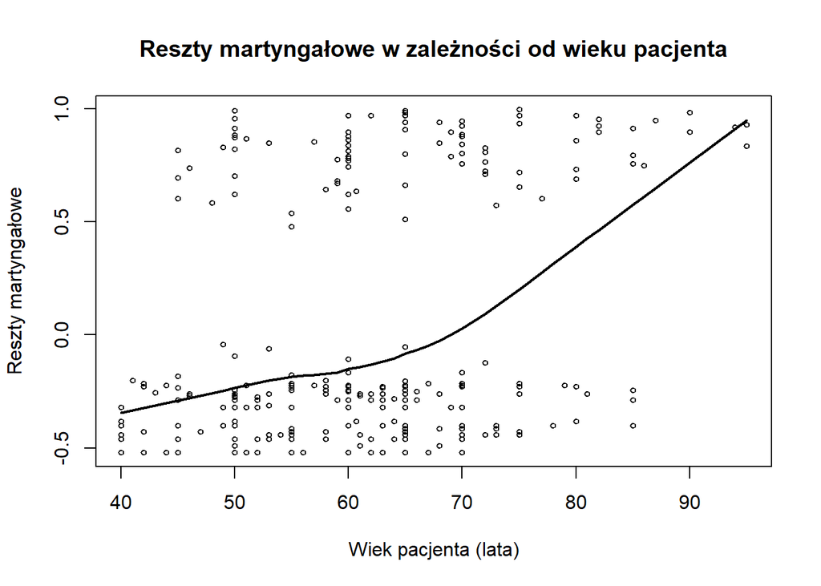

```r
     zmn1 <- data_1$age
     lab1 <- "Wiek pacjenta (lata)"
     reszty1 <- resid(coxph(Surv(time,DEATH_EVENT)~1,data=data_1),type="martingale")
     plot(zmn1, reszty1, main="Reszty martyngałowe w zależności od wieku pacjenta", xlab=lab1,ylab="Reszty martyngałowe",cex=0.6)
     lines(lowess(zmn1, reszty1,delta=1),lwd=2)
```

## 8.2 Reszty martyngałowe dla zmiennej creatinine_phosphokinase

**creatinine_phosphokinase - liniowość**

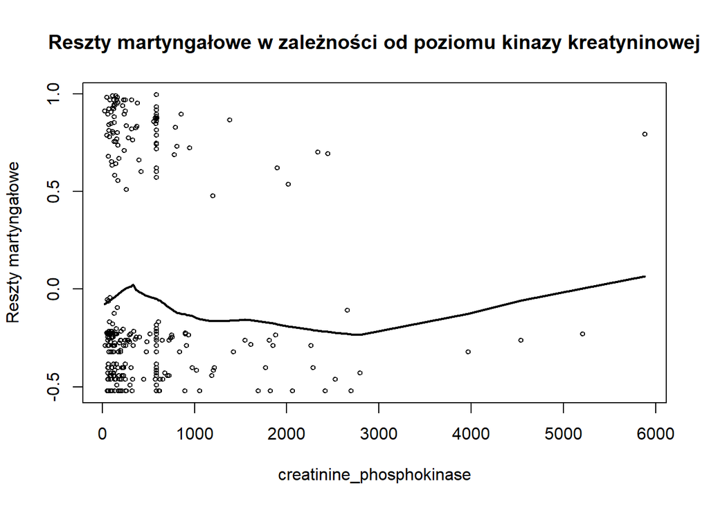

```r
     zmn2 <- data_1$creatinine_phosphokinase
     lab2 <- "creatinine_phosphokinase"
     reszty2 <- resid(coxph(Surv(time,DEATH_EVENT)~1,data=data_1),type="martingale")
     plot(zmn2, reszty2,main = "Reszty martyngałowe w zależności od poziomu kinazy kreatyninowej", xlab=lab2,ylab="Reszty martyngałowe",cex=0.6)
     lines(lowess(zmn2, reszty2,delta=1),lwd=2)
```

## 8.3 Reszty martyngałowe dla zmiennej serum_creatinine

**serum_creatinine - nie występuje liniowość**

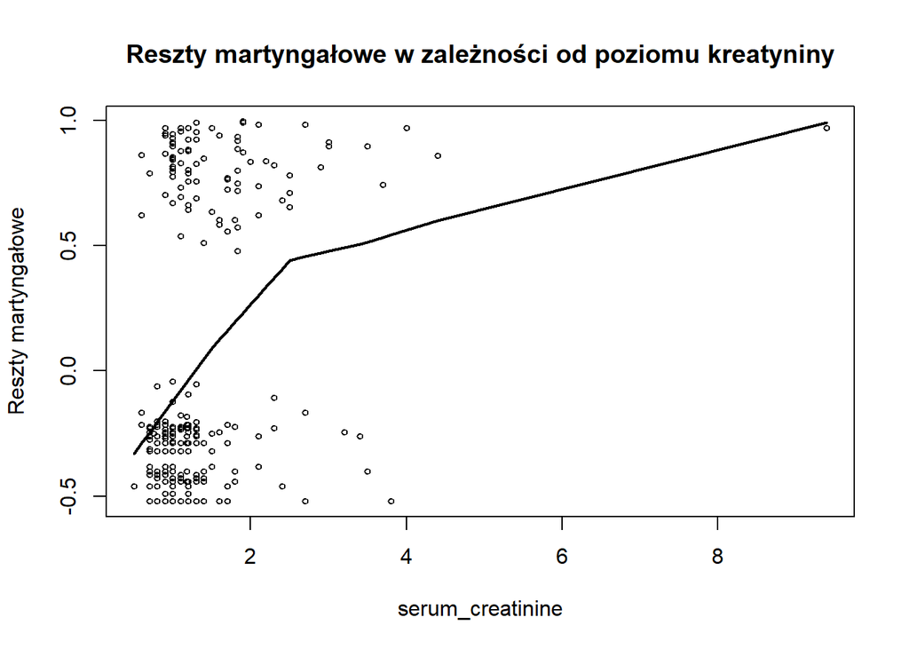

```r
     zmn3 <- data_1$serum_creatinine
     lab3 <- "serum_creatinine"
     reszty3 <- resid(coxph(Surv(time,DEATH_EVENT)~1,data=data_1),type="martingale")
     plot(zmn3, reszty3, main = "Reszty martyngałowe w zależności od poziomu kreatyniny", xlab=lab3,ylab="Reszty martyngałowe",cex=0.6)
     lines(lowess(zmn3, reszty3,delta=1),lwd=2)
```

## 8.4 Reszty martyngałowe dla zmiennej serum_sodium

**serum_sodium - nie występuje liniowość**

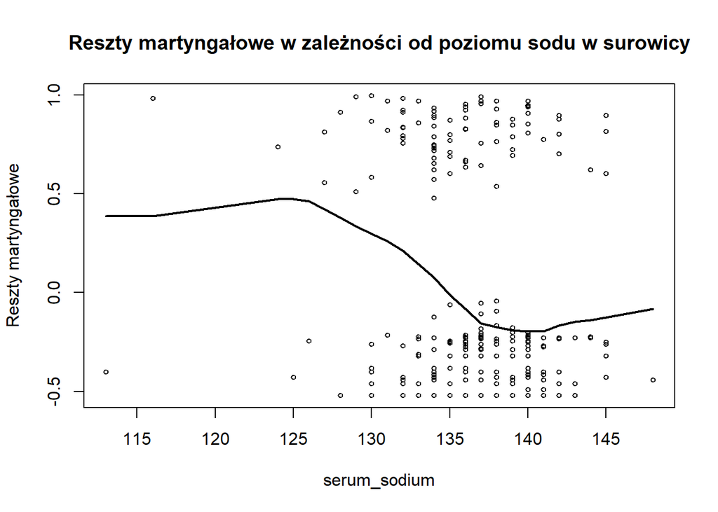

```r
     zmn4 <- data_1$serum_sodium
     lab4 <- "serum_sodium"
     reszty4 <- resid(coxph(Surv(time,DEATH_EVENT)~1,data=data_1),type="martingale")
     plot(zmn4, reszty4,main = "Reszty martyngałowe w zależności od poziomu sodu w surowicy", xlab=lab4,ylab="Reszty martyngałowe",cex=0.6)
     lines(lowess(zmn4, reszty4,delta=1),lwd=2)
```

## 8.5 TRANSFORMACJA ZMIENNEJ creatinine_phosphokinase

### 8.5.1 Dychotomizacja

**Wartość przed dychotymizacją:**

```r
     Cox_dla_creatinine_phosphokinase <- coxph(Surv(time, DEATH_EVENT)~zmn2,data=data_1)
     A1_dla_creatinine_phosphokinase <- round(AIC(Cox_jednostki_wplywowe),2) #akaike z modelu coxa
     A1_dla_creatinine_phosphokinase
```

```
## [1] 845.69
```

```r
     cutpoint_dla_creatinine_phosphokinase <- cutp(Cox_dla_creatinine_phosphokinase)$zmn2 ## optymalny punkt odciecia
     c_dla_creatinine_phosphokinase <- (zmn2>=cutpoint_dla_creatinine_phosphokinase$zmn2[1])*1+0 #jezeli zmienna jest >= punktowi odciecia to przypisuje 1 w      przeciwnym wypadku 0
```

**Wartość po dychotymizacji:**

```r
     Cox_dla_creatinine_phosphokinase_d <- coxph(Surv(time, DEATH_EVENT)~c_dla_creatinine_phosphokinase,data=data_1)
     A2_dla_creatinine_phosphokinase <- round(AIC(Cox_dla_creatinine_phosphokinase_d),2)
     A2_dla_creatinine_phosphokinase
```

```
## [1] 900.67
```

**Interpretacja:**

Otrzymaliśmy gorszy wynik, ponieważ Akaike jest dużo wyższy niz przed dychotomizacją

### 8.5.2 Wielomiany ulamkowe dla creatinine_phosphokinase

```r
     m3_dla_creatinine_phosphokinase <- mfp(Surv(time,DEATH_EVENT)~ fp(zmn2, df = 4, select = 0.05),family=cox, data=data_1)
     m3_dla_creatinine_phosphokinase
```

```
## Call:
## mfp(formula = Surv(time, DEATH_EVENT) ~ fp(zmn2, df = 4, select = 0.05),
##     data = data_1, family = cox)
##
##
## Deviance table:
##           Resid. Dev
## Null model    903.3419
## Linear model  902.3421
## Final model   903.3419
##
## Fractional polynomials:
##      df.initial select alpha df.final power1 power2
## zmn2          4   0.05  0.05        0      .      .
##
##
## Transformations of covariates:
##      formula
## zmn2       .
##
##
## Null model
##  log likelihood= -451.7
##  n= 285
```

```r
     A3_dla_creatinine_phosphokinase <- round(AIC(m3_dla_creatinine_phosphokinase),2)
     A3_dla_creatinine_phosphokinase
```

```
## [1] NA
```

### 8.5.3 Metoda wielomianowej funkcji sklejanej (splajn) dla creatinine_phosphokinase

**Interpretacja:**

- Względny hazard początkowo wzrasta dla niższych wartości CPK, a następnie spada, po czym ponownie wzrasta dla wyższych wartości.
- Duża niepewność (szeroki przedział ufności) dla bardzo wysokich wartości CPK sugeruje mniejszą liczbę obserwacji w tym zakresie.
- Gdy hazard względny jest powyżej 1, oznacza to zwiększone ryzyko śmierci w porównaniu do wartości odniesienia (np. średniego poziomu CPK).

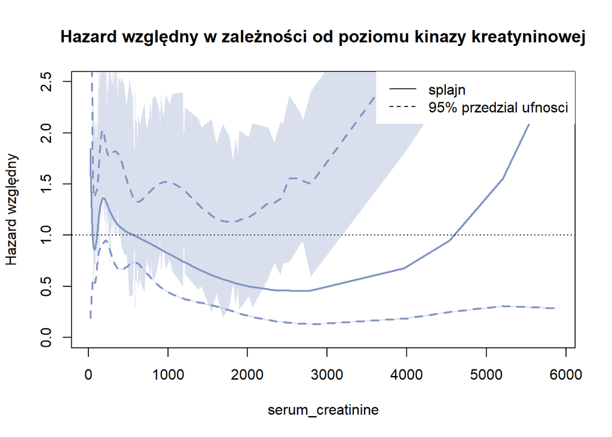

```r
     int_dla_creatinine_phosphokinase <- quantile(na.omit(zmn2),probs=c(0.05,0.275,.5,.725,.95))
     Cox_dla_creatinine_phosphokinase2 <- coxph(Surv(time,DEATH_EVENT)~ns(zmn2,knots=int_dla_creatinine_phosphokinase),data=data_1)
     pred <- predict(Cox_dla_creatinine_phosphokinase2,type="terms",se.fit=TRUE, terms=1)
     plot(na.omit(zmn2),exp(pred$fit),type="n",main = "Hazard względny w zależności od poziomu kinazy kreatyninowej",xlab=lab3,ylim=c(0,2.5),
          ylab="Hazard względny")
     lines(smooth.spline(na.omit(zmn2),exp(pred$fit+1.96*pred$se.fit)),lty=2)
     lines(smooth.spline(na.omit(zmn2),exp(pred$fit-1.96*pred$se.fit)),lty=2)
     lines(smooth.spline(na.omit(zmn2),exp(pred$fit)),lty=1)
     abline(h=1,lty=3)
     legend('topright',2,c("splajn","95% przedzial ufnosci"), lty=1:2, box.lty=0)
```

```r
     A4_dla_creatinine_phosphokinase  <- round(AIC(Cox_dla_creatinine_phosphokinase2),2)
     A4_dla_creatinine_phosphokinase
```

```
## [1] 910.21
```

## 8.6 TRANSFORMACJA ZMIENNEJ serum_creatinine

### 8.6.1 Dychotomizacja

**Wartość przed dychotymizacją:**

```r
     Cox_dla_serum_creatinine <- coxph(Surv(time, DEATH_EVENT)~zmn3,data=data_1)
     A1_dla_serum_creatinine <- round(AIC(Cox_jednostki_wplywowe),2) #akaike z modelu coxa
     A1_dla_serum_creatinine
```

```
## [1] 845.69
```

```r
     cutpoint_dla_serum_creatinine <- cutp(Cox_dla_serum_creatinine)$zmn3 ## optymalny punkt odciecia
     c_dla_serum_creatinine <- (zmn3>=cutpoint_dla_serum_creatinine$zmn3[1])*1+0 #jezeli zmienna jest >= punkotwi odciecia to przypisuje 1 w      przeciwnym wypadku 0
```

**Wartość po dychotymizacji:**

```r
     Cox_dla_serum_creatinine_d <- coxph(Surv(time, DEATH_EVENT)~c_dla_serum_creatinine,data=data_1)
     A2_dla_serum_creatinine <- round(AIC(Cox_dla_serum_creatinine_d),2)
     A2_dla_serum_creatinine
```

```
## [1] 877.47
```

**Interpretacja:**

Otrzymaliśmy gorszy wynik, ponieważ Akaike jest dużo wyższy niz przed dychotomizacją

### 8.6.2 Wielomiany ulamkowe dla serum_creatinine

```r
     m3_dla_serum_creatinine <- mfp(Surv(time,DEATH_EVENT)~ fp(zmn3, df = 4, select = 0.05),family=cox, data=data_1)
     m3_dla_serum_creatinine
```

```
## Call:
## mfp(formula = Surv(time, DEATH_EVENT) ~ fp(zmn3, df = 4, select = 0.05),
##     data = data_1, family = cox)
##
##
## Deviance table:
##           Resid. Dev
## Null model    903.3419
## Linear model  874.3994
## Final model   864.9143
##
## Fractional polynomials:
##      df.initial select alpha df.final power1 power2
## zmn3          4   0.05  0.05        2   -0.5      .
##
##
## Transformations of covariates:
##           formula
## zmn3 I(zmn3^-0.5)
##
##         coef exp(coef) se(coef)      z        p
## zmn3.1 -3.88   0.02065    0.608 -6.382 1.75e-10
##
## Likelihood ratio test=38.43  on 1 df, p=5.682e-10 n= 285
```

```r
     A3_dla_serum_creatinine <- round(AIC(m3_dla_serum_creatinine))
     A3_dla_serum_creatinine
```

```
## [1] 867
```

### 8.6.3 Metoda wielomianowej funkcji sklejanej (splajn) dla serum_creatinine

**Interpretacja:**

- Dla bardzo niskich wartości kreatyniny (<1 mg/dL) hazard względny jest niestabilny i ma szeroki przedział ufności, co sugeruje małą liczbę obserwacji w tej grupie.
- Dla wartości 1-2 mg/dL hazard względny wzrasta, po czym nieznacznie spada.
- Dla wyższych wartości kreatyniny (>3 mg/dL) hazard względny ponownie wzrasta, co sugeruje zwiększone ryzyko śmierci u pacjentów z wysokim poziomem kreatyniny (co może być związane z niewydolnością nerek).
- Szerokie przedziały ufności dla skrajnych wartości wskazują na dużą niepewność estymacji w tych zakresach.

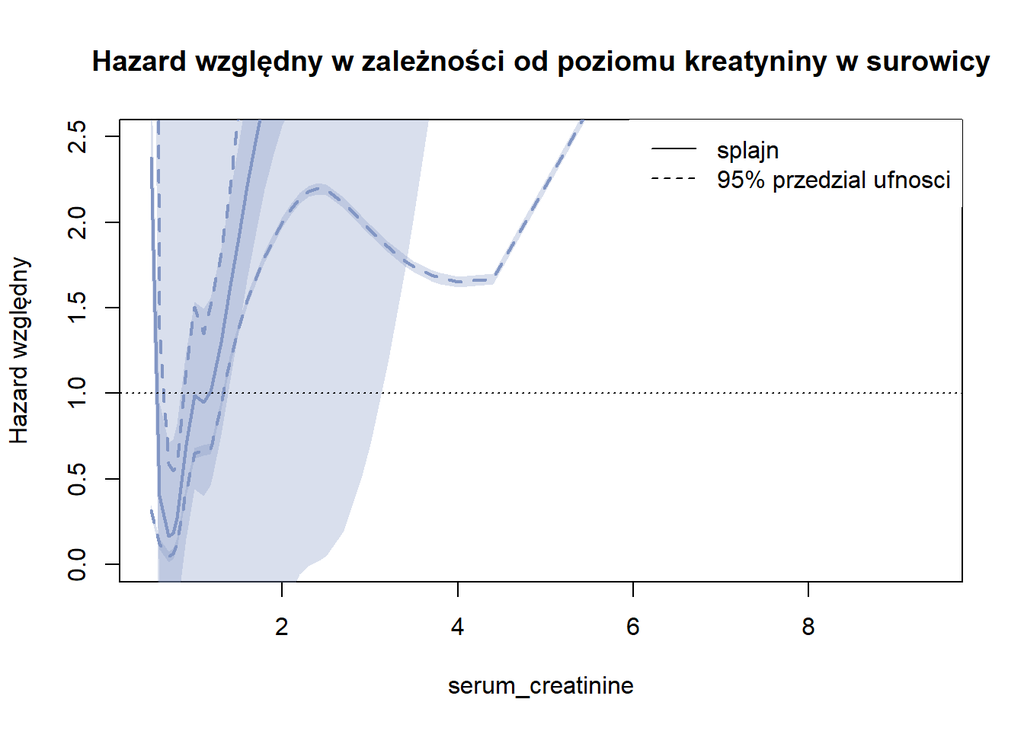

```r
     int_dla_serum_creatinine <- quantile(na.omit(zmn3),probs=c(0.05,0.275,.5,.725,.95))
     Cox_dla_serum_creatinine2 <- coxph(Surv(time,DEATH_EVENT)~ns(zmn3,knots=int_dla_serum_creatinine),data=data_1)
     pred2 <- predict(Cox_dla_serum_creatinine2,type="terms",se.fit=TRUE, terms=1)
     plot(na.omit(zmn3),exp(pred2$fit),type="n",main="Hazard względny w zależności od poziomu kreatyniny w surowicy",xlab=lab3,ylim=c(0,2.5),
          ylab="Hazard względny")
     lines(smooth.spline(na.omit(zmn3),exp(pred2$fit+1.96*pred2$se.fit)),lty=2)
     lines(smooth.spline(na.omit(zmn3),exp(pred2$fit-1.96*pred2$se.fit)),lty=2)
     lines(smooth.spline(na.omit(zmn3),exp(pred2$fit)),lty=1)
     abline(h=1,lty=3)
     legend('topright',2,c("splajn","95% przedzial ufnosci"), lty=1:2, box.lty=0)
```

```r
     A4_dla_serum_creatinine  <- round(AIC(Cox_dla_serum_creatinine2),2)
     A4_dla_serum_creatinine
```

```
## [1] 868.47
```

## 8.7 TRANSFORMACJA ZMIENNEJ serum_sodium

### 8.7.1 Dychotomizacja

**Wartość przed dychotymizacją:**

```r
     Cox_dla_serum_sodium <- coxph(Surv(time, DEATH_EVENT)~zmn4,data=data_1)
     A1_dla_serum_sodium <- round(AIC(Cox_jednostki_wplywowe),2) #akaike z modelu coxa
     A1_dla_serum_sodium
```

```
## [1] 845.69
```

```r
     cutpoint_dla_serum_sodium <- cutp(Cox_dla_serum_sodium)$zmn4 ## optymalny punkt odciecia
     c_dla_serum_sodium <- (zmn4>=cutpoint_dla_serum_sodium$zmn4[1])*1+0 #jezeli zmienna jest >= punkotwi odciecia to przypisuje 1 w      przeciwnym wypadku 0
```

**Wartość po dychotymizacji:**

```r
     Cox_dla_serum_sodium_d <- coxph(Surv(time, DEATH_EVENT)~c_dla_serum_sodium,data=data_1)
     A2_dla_serum_sodium <- round(AIC(Cox_dla_serum_sodium_d),2)
     A2_dla_serum_sodium
```

```
## [1] 889.61
```

**Interpretacja:**

Otrzymaliśmy gorszy wynik, ponieważ Akaike jest dużo wyższy niz przed dychotomizacją

### 8.7.2 Wielomiany ulamkowe dla serum_sodium

```r
     m3_dla_serum_sodium <- mfp(Surv(time,DEATH_EVENT)~ fp(zmn4, df = 4, select = 0.05),family=cox, data=data_1)
     m3_dla_serum_sodium
```

```
## Call:
## mfp(formula = Surv(time, DEATH_EVENT) ~ fp(zmn4, df = 4, select = 0.05),
##     data = data_1, family = cox)
##
##
## Deviance table:
##           Resid. Dev
## Null model    903.3419
## Linear model  893.579
## Final model   893.579
##
## Fractional polynomials:
##      df.initial select alpha df.final power1 power2
## zmn4          4   0.05  0.05        1      1      .
##
##
## Transformations of covariates:
##              formula
## zmn4 I((zmn4/100)^1)
##
##          coef exp(coef) se(coef)      z        p
## zmn4.1 -6.973 0.0009368    2.041 -3.417 0.000633
##
## Likelihood ratio test=9.76  on 1 df, p=0.001781 n= 285
```

```r
     A3_dla_serum_sodium <- round(AIC(m3_dla_serum_sodium))
     A3_dla_serum_sodium
```

```
## [1] 896
```

### 8.7.3 Metoda wielomianowej funkcji sklejanej (splajn) dla serum_sodium

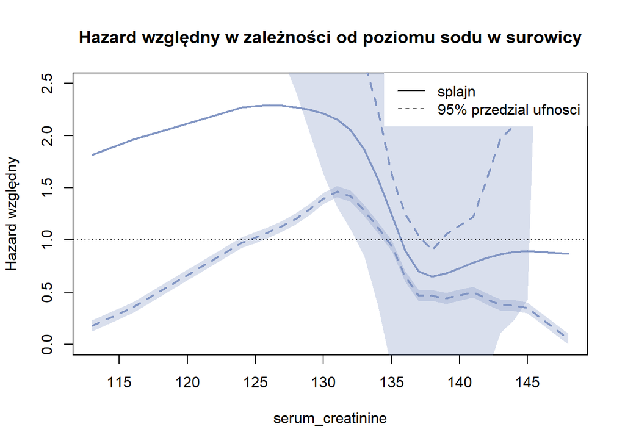

```r
     int_dla_serum_sodium <- quantile(na.omit(zmn4),probs=c(0.05,0.275,.5,.725,.95))
     Cox_dla_serum_sodium2 <- coxph(Surv(time,DEATH_EVENT)~ns(zmn4,knots=int_dla_serum_sodium),data=data_1)
     pred3 <- predict(Cox_dla_serum_sodium2,type="terms",se.fit=TRUE, terms=1)
     plot(na.omit(zmn4),exp(pred3$fit),type="n",main="Hazard względny w zależności od poziomu sodu w surowicy",xlab=lab3,ylim=c(0,2.5),
          ylab="Hazard względny")
     lines(smooth.spline(na.omit(zmn4),exp(pred3$fit+1.96*pred3$se.fit)),lty=2)
     lines(smooth.spline(na.omit(zmn4),exp(pred3$fit-1.96*pred3$se.fit)),lty=2)
     lines(smooth.spline(na.omit(zmn4),exp(pred3$fit)),lty=1)
     abline(h=1,lty=3)
     legend('topright',2,c("splajn","95% przedzial ufnosci"), lty=1:2, box.lty=0)
```

```r
     A4_dla_serum_sodium  <- round(AIC(Cox_dla_serum_sodium2),2)
     A4_dla_serum_sodium
```

```
## [1] 898.65
```

## 8.8 PODSUMOWANIE TRANSFORMACJI ZMIENNYCH

**Transformacje zmiennej creatinine_phosphokinase:**

- A1_dla_creatinine_phosphokinase - model bez tranformacji
- A2_dla_creatinine_phosphokinase - po dychotomizacji
- A3_dla_creatinine_phosphokinase - wielomiany ułamkowe
- A4_dla_creatinine_phosphokinase - splajn

```r
rbind(A1_dla_creatinine_phosphokinase,A2_dla_creatinine_phosphokinase,A3_dla_creatinine_phosphokinase,A4_dla_creatinine_phosphokinase)
```

```
##                                   [,1]
## A1_dla_creatinine_phosphokinase 845.69
## A2_dla_creatinine_phosphokinase 900.67
## A3_dla_creatinine_phosphokinase     NA
## A4_dla_creatinine_phosphokinase 910.21
```

**Transformacje zmiennej serum_creatinine:**

- A1_dla_serum_creatinine - model bez tranformacji
- A2_dla_serum_creatinine - po dychotomizacji
- A3_dla_serum_creatinine - wielomiany ułamkowe
- A4_dla_serum_creatinine - splajn

```r
rbind(A1_dla_serum_creatinine,A2_dla_serum_creatinine,A3_dla_serum_creatinine,A4_dla_serum_creatinine)
```

```
##                           [,1]
## A1_dla_serum_creatinine 845.69
## A2_dla_serum_creatinine 877.47
## A3_dla_serum_creatinine 867.00
## A4_dla_serum_creatinine 868.47
```

**Transformacje zmiennej serum_sodium:**

- A1_dla_serum_sodium - model bez tranformacji
- A2_dla_serum_sodium - po dychotomizacji
- A3_dla_serum_sodium - wielomiany ułamkowe
- A4_dla_serum_sodium - splajn

```r
rbind(A1_dla_serum_sodium,A2_dla_serum_sodium,A3_dla_serum_sodium,A4_dla_serum_sodium)
```

```
##                       [,1]
## A1_dla_serum_sodium 845.69
## A2_dla_serum_sodium 889.61
## A3_dla_serum_sodium 896.00
## A4_dla_serum_sodium 898.65
```

Mimo wszystko najlepszym modelem jest model bez transformacji zmiennych, czyli:

```r
  summary(Cox_jednostki_wplywowe)
```

```
## Call:
## coxph(formula = Surv(time, DEATH_EVENT) ~ age + anaemia + creatinine_phosphokinase +
##     high_blood_pressure + serum_creatinine + serum_sodium, data = data_1)
##
##   n= 285, number of events= 86
##
##                                coef  exp(coef)   se(coef)      z Pr(>|z|)
## age                       5.030e-02  1.052e+00  9.783e-03  5.141 2.73e-07 ***
## anaemia1                  3.942e-01  1.483e+00  2.250e-01  1.752  0.07974 .
## creatinine_phosphokinase -2.396e-05  1.000e+00  1.665e-04 -0.144  0.88554
## high_blood_pressure1      5.583e-01  1.748e+00  2.263e-01  2.467  0.01363 *
## serum_creatinine          3.798e-01  1.462e+00  8.671e-02  4.380 1.19e-05 ***
## serum_sodium             -6.231e-02  9.396e-01  2.328e-02 -2.676  0.00745 **
## ---
## Signif. codes:  0 '***' 0.001 '**' 0.01 '*' 0.05 '.' 0.1 ' ' 1
##
##                          exp(coef) exp(-coef) lower .95 upper .95
## age                         1.0516     0.9509    1.0316    1.0719
## anaemia1                    1.4832     0.6742    0.9543    2.3052
## creatinine_phosphokinase    1.0000     1.0000    0.9996    1.0003
## high_blood_pressure1        1.7478     0.5722    1.1216    2.7236
## serum_creatinine            1.4619     0.6840    1.2334    1.7327
## serum_sodium                0.9396     1.0643    0.8977    0.9835
##
## Concordance= 0.74  (se = 0.027 )
## Likelihood ratio test= 69.65  on 6 df,   p=5e-13
## Wald test            = 85.32  on 6 df,   p=3e-16
## Score (logrank) test = 93.71  on 6 df,   p=<2e-16
```

# 9 Miary Dopasowania

Poniżej ukazano miary dopasowania R2, (obliczone na podstawie statystyki cząstkowej ilorazu wiarygodności w modelu Coxa) Najlepiej dopasowanym modelem (o największej wartości tej miary = 0,57) jest model cox1_po_AIC otrzymany metodą krokową, przed odrzuceniem zmiennych niespełniajacych założeń proporcjonalnosci oraz jednostek odstających i wpływowych.

```r
     r2_1 <- coxr2(cox1_po_AIC) #model otrzymany metoda krokowa przed sprawdzeniem zalozen proporcjonalnosci (uznany za najlepszy)
     r2_2 <- coxr2(cox1_po_procjonalnosci) #model po odrzuceniu zmiennych niespelniajacych zalozen proporcjonalnosci
     r2_3 <- coxr2(Cox_jednostki_wplywowe) #model po odrzuceniu jednostek odstajacych i wplywowych
     round(rbind(r2_1$rsq, r2_2$rsq, r2_3$rsq),2)
```

```
##       rsq
## [1,] 0.57
## [2,] 0.45
## [3,] 0.56
```

# 10 Wskaznik Briera

**Interpretacja:**

**Zakres wartości wskaźnika Briera:**

0 → Idealna prognoza (brak błędu, pewność co do poprawnej prognozy) 0.25 → Przypadkowe przewidywania dla problemu dwuklasowego (np. rzut monetą dla klasyfikacji 0/1) 1 → Najgorsza możliwa prognoza (pewność co do złego wyniku)